# Patient Length of Stay - Solution

www.PredictiveInsightsAI.com Solution to SOA PA 6/18/20

13 October, 2020

For your convenience, this solution document has been formatted to be easy to read. When taking this exam, candidates are not expected to make their `.Rmd` documents look this way. The `make_table` function is included only to improve your reading experience. The SOA’s instructions from the Project Statement say only that

> At a minimum you must submit your completed report template and an Rmd file that supports your work. Graders expect that your Rmd code can be run from beginning to end. The code snippets provided should either be commented out or adapted for execution. Ensure that it is clear where in the code each of the Tasks is addressed. Documentation of your thought process and conclusion for each Task should be completely contained within your Word report. The Rmd code should be clear, may contain commentary, and support your work.

Your assistant has provided the following code to load the dataset and provide summary values.

```r
#NO CHANGES NEEDED

# Load packages and data

# Load packages
library(tidyverse)
library(kableExtra) #If needed, install this package.  It's just used for making tables.
library(ExamPAData)
library(plyr)
library(dplyr)

theme_set(theme_minimal())

#function to create html tables
make_table <- function(df, caption = ""){
  df %>%
    kable(caption = caption) %>%
    kable_styling(bootstrap_options = "striped", full_width = F)}

#global chunk options
knitr::opts_chunk$set(warning = F, message = F, echo = T, fig.width = 14, fig.height = 8)

# Load data
data.all <- patient_length_of_stay
summary(data.all)
```

```
##       days          gender              age                race
##  Min.   : 1.00   Length:10000       Length:10000       Length:10000
##  1st Qu.: 2.00   Class :character   Class :character   Class :character
##  Median : 4.00   Mode  :character   Mode  :character   Mode  :character
##  Mean   : 4.41
##  3rd Qu.: 6.00
##  Max.   :14.00
##     weight          admit_type_id    metformin           insulin
##  Length:10000       Min.   :1.000   Length:10000       Length:10000
##  Class :character   1st Qu.:1.000   Class :character   Class :character
##  Mode  :character   Median :1.000   Mode  :character   Mode  :character
##                     Mean   :1.857
##                     3rd Qu.:3.000
##                     Max.   :4.000
##   readmitted          num_procs        num_meds         num_ip
##  Length:10000       Min.   :0.000   Min.   : 1.00   Min.   : 0.000
##  Class :character   1st Qu.:0.000   1st Qu.:10.00   1st Qu.: 0.000
##  Mode  :character   Median :1.000   Median :15.00   Median : 0.000
##                     Mean   :1.345   Mean   :16.16   Mean   : 0.639
##                     3rd Qu.:2.000   3rd Qu.:20.00   3rd Qu.: 1.000
##                     Max.   :6.000   Max.   :67.00   Max.   :21.000
##    num_diags
##  Min.   : 1.000
##  1st Qu.: 6.000
##  Median : 8.000
##  Mean   : 7.442
##  3rd Qu.: 9.000
##  Max.   :16.000
```

```r
str(data.all)
```

```
## tibble [10,000 x 13] (S3: spec_tbl_df/tbl_df/tbl/data.frame)
##  $ days         : num [1:10000] 1 5 2 12 6 3 1 3 9 1 ...
##  $ gender       : chr [1:10000] "Male" "Male" "Female" "Male" ...
##  $ age          : chr [1:10000] "[70-80)" "[70-80)" "[80-90)" "[50-60)" ...
##  $ race         : chr [1:10000] "AfricanAmerican" "Caucasian" "Caucasian" "Caucasian" ...
##  $ weight       : chr [1:10000] "?" "?" "?" "?" ...
##  $ admit_type_id: num [1:10000] 1 3 2 1 2 2 1 1 4 1 ...
##  $ metformin    : chr [1:10000] "No" "No" "No" "No" ...
##  $ insulin      : chr [1:10000] "Down" "Steady" "Steady" "Up" ...
##  $ readmitted   : chr [1:10000] ">30" ">30" "NO" ">30" ...
##  $ num_procs    : num [1:10000] 0 5 1 2 2 1 0 0 0 0 ...
##  $ num_meds     : num [1:10000] 10 13 10 32 16 17 12 11 9 13 ...
##  $ num_ip       : num [1:10000] 0 0 0 0 1 0 0 0 0 0 ...
##  $ num_diags    : num [1:10000] 8 9 7 9 5 8 7 8 5 6 ...
##  - attr(*, "spec")=
##   .. cols(
##   ..   days = col_double(),
##   ..   gender = col_character(),
##   ..   age = col_character(),
##   ..   race = col_character(),
##   ..   weight = col_character(),
##   ..   admit_type_id = col_double(),
##   ..   metformin = col_character(),
##   ..   insulin = col_character(),
##   ..   readmitted = col_character(),
##   ..   num_procs = col_double(),
##   ..   num_meds = col_double(),
##   ..   num_ip = col_double(),
##   ..   num_diags = col_double()
##   .. )
```

```r
data.all %>% mutate_if(is.character, as.factor) %>% summary()
```

```
##       days                   gender          age                    race
##  Min.   : 1.00   Female         :5338   [70-80):2541   ?              : 226
##  1st Qu.: 2.00   Male           :4659   [60-70):2229   AfricanAmerican:1850
##  Median : 4.00   Unknown/Invalid:   3   [50-60):1727   Asian          :  63
##  Mean   : 4.41                          [80-90):1676   Caucasian      :7532
##  3rd Qu.: 6.00                          [40-50): 931   Hispanic       : 199
##  Max.   :14.00                          [30-40): 372   Other          : 130
##                                         (Other): 524
##        weight     admit_type_id    metformin      insulin     readmitted
##  ?        :9691   Min.   :1.000   Down  :  60   Down  :1198   <30:1102
##  [75-100) : 133   1st Qu.:1.000   No    :8026   No    :4742   >30:3527
##  [50-75)  :  84   Median :1.000   Steady:1800   Steady:2929   NO :5371
##  [100-125):  63   Mean   :1.857   Up    : 114   Up    :1131
##  [25-50)  :  10   3rd Qu.:3.000
##  [125-150):   9   Max.   :4.000
##  (Other)  :  10
##    num_procs        num_meds         num_ip         num_diags
##  Min.   :0.000   Min.   : 1.00   Min.   : 0.000   Min.   : 1.000
##  1st Qu.:0.000   1st Qu.:10.00   1st Qu.: 0.000   1st Qu.: 6.000
##  Median :1.000   Median :15.00   Median : 0.000   Median : 8.000
##  Mean   :1.345   Mean   :16.16   Mean   : 0.639   Mean   : 7.442
##  3rd Qu.:2.000   3rd Qu.:20.00   3rd Qu.: 1.000   3rd Qu.: 9.000
##  Max.   :6.000   Max.   :67.00   Max.   :21.000   Max.   :16.000
##
```

# Task 1

Edit the data for missing and invalid data.

Generic code has been provided to edit the data. You can modify and use some or all of this code to edit the data.

Convert numeric variable type to factor variable type

```r
# Replace VARIABLE with the variable name of the variable to be changed.

#data.all$VARIABLE <- as.factor(data.all$VARIABLE) # Replace VARIABLE twice
#str(data.all)

data.all$age <- as.factor(data.all$age) # Replace VARIABLE twice
data.all$admit_type_id <- as.factor(data.all$admit_type_id) # Replace VARIABLE twice

data.all <- data.all %>% filter(gender != "Unknown/Invalid:")

data.all <- data.all %>% filter(gender %in% c("Male", "Female"))

#gender_missing <- data.all$gender == "Unknown/Invalid:"
#data.all <- data.all[-gender_missing,]

data.all <- data.all %>% mutate(race = ifelse(race == "?", "Other", race))

#data.all$race <- ifelse(data.all$race == "?", "Other", data.all$race)

data.all <- data.all %>% select(-weight)
data.all$weight <- NULL # Replace VARIABLE

data.all <- data.all %>% mutate(race = ifelse(race == "Asian", "Other", race))
data.all$race <- ifelse(data.all$race=="Asian", "Other", data.all$race)

library(forcats)
data.all <- data.all <- data.all %>% mutate_if(is.factor, fct_infreq)

data.all <- data.all <- data.all %>% mutate_if(is.character, fct_infreq)

summary(data.all)
```

```
##       days           gender          age                    race
##  Min.   : 1.000   Female:5338   [70-80):2541   Caucasian      :7531
##  1st Qu.: 2.000   Male  :4659   [60-70):2228   AfricanAmerican:1848
##  Median : 4.000                 [50-60):1726   Other          : 419
##  Mean   : 4.409                 [80-90):1676   Hispanic       : 199
##  3rd Qu.: 6.000                 [40-50): 931
##  Max.   :14.000                 [30-40): 372
##                                 (Other): 523
##  admit_type_id  metformin      insulin     readmitted   num_procs
##  1:5289        No    :8024   No    :4742   NO :5370   Min.   :0.000
##  2:1870        Steady:1799   Steady:2928   >30:3525   1st Qu.:0.000
##  3:1817        Up    : 114   Down  :1198   <30:1102   Median :1.000
##  4:1021        Down  :  60   Up    :1129              Mean   :1.345
##                                                       3rd Qu.:2.000
##                                                       Max.   :6.000
##
##     num_meds         num_ip          num_diags
##  Min.   : 1.00   Min.   : 0.0000   Min.   : 1.000
##  1st Qu.:10.00   1st Qu.: 0.0000   1st Qu.: 6.000
##  Median :15.00   Median : 0.0000   Median : 8.000
##  Mean   :16.16   Mean   : 0.6388   Mean   : 7.442
##  3rd Qu.:20.00   3rd Qu.: 1.0000   3rd Qu.: 9.000
##  Max.   :67.00   Max.   :21.0000   Max.   :16.000
##
```

```r
data.all %>% dplyr::count(num_procs)
```

```
## # A tibble: 7 x 2
##   num_procs     n
##       <dbl> <int>
## 1         0  4561
## 2         1  2064
## 3         2  1223
## 4         3   969
## 5         4   391
## 6         5   274
## 7         6   515
```

```r
data.all %>% dplyr::count(num_meds)
```

```
## # A tibble: 64 x 2
##    num_meds     n
##       <dbl> <int>
##  1        1    24
##  2        2    40
##  3        3   102
##  4        4   143
##  5        5   171
##  6        6   262
##  7        7   342
##  8        8   439
##  9        9   461
## 10       10   517
## # ... with 54 more rows
```

```r
data.all %>% dplyr::count(num_ip)
```

```
## # A tibble: 15 x 2
##    num_ip     n
##     <dbl> <int>
##  1      0  6644
##  2      1  1888
##  3      2   778
##  4      3   335
##  5      4   154
##  6      5    79
##  7      6    45
##  8      7    27
##  9      8    15
## 10      9    12
## 11     10     4
## 12     11     7
## 13     12     3
## 14     13     5
## 15     21     1
```

```r
data.all %>% dplyr::count(num_diags)
```

```
## # A tibble: 14 x 2
##    num_diags     n
##        <dbl> <int>
##  1         1    23
##  2         2    96
##  3         3   267
##  4         4   570
##  5         5  1063
##  6         6   992
##  7         7   996
##  8         8  1069
##  9         9  4914
## 10        10     2
## 11        11     1
## 12        13     2
## 13        14     1
## 14        16     1
```

```r
summary(data.all)
```

```
##       days           gender          age                    race
##  Min.   : 1.000   Female:5338   [70-80):2541   Caucasian      :7531
##  1st Qu.: 2.000   Male  :4659   [60-70):2228   AfricanAmerican:1848
##  Median : 4.000                 [50-60):1726   Other          : 419
##  Mean   : 4.409                 [80-90):1676   Hispanic       : 199
##  3rd Qu.: 6.000                 [40-50): 931
##  Max.   :14.000                 [30-40): 372
##                                 (Other): 523
##  admit_type_id  metformin      insulin     readmitted   num_procs
##  1:5289        No    :8024   No    :4742   NO :5370   Min.   :0.000
##  2:1870        Steady:1799   Steady:2928   >30:3525   1st Qu.:0.000
##  3:1817        Up    : 114   Down  :1198   <30:1102   Median :1.000
##  4:1021        Down  :  60   Up    :1129              Mean   :1.345
##                                                       3rd Qu.:2.000
##                                                       Max.   :6.000
##
##     num_meds         num_ip          num_diags
##  Min.   : 1.00   Min.   : 0.0000   Min.   : 1.000
##  1st Qu.:10.00   1st Qu.: 0.0000   1st Qu.: 6.000
##  Median :15.00   Median : 0.0000   Median : 8.000
##  Mean   :16.16   Mean   : 0.6388   Mean   : 7.442
##  3rd Qu.:20.00   3rd Qu.: 1.0000   3rd Qu.: 9.000
##  Max.   :67.00   Max.   :21.0000   Max.   :16.000
##
```

Remove variables / columns

```r
# Replace VARIABLE with the variable name of the variable to be removed.

data.all$VARIABLE <- NULL # Replace VARIABLE
head(data.all)
```

Remove observations / rows

```r
# Replace VARIABLE with the variable name with values to be removed.
# Replace VALUE with the value of the variable to be removed.

data.all <- subset(data.all, VARIABLE != "VALUE") # Replace VARIABLE and VALUE
# Value is in quotation marks for factor variables. No quotation marks for numeric variables.

data.all$VARIABLE <- droplevels(data.all$VARIABLE) # If VARIABLE is a factor variable this must be run else the dropped factor level will be retained, but with zero observations.

summary(data.all$VARIABLE)
```

Combine variable levels

```r
# Replace VARIABLE with the variable name to have reduced number of levels.
# Replace LEVELs with new level names.

print("Data Before Combine Levels")
table(data.all$VARIABLE) # Replace VARIABLE

# Combine levels of VARIABLE by mapping one level to another level

var.levels <- levels(data.all$VARIABLE) # Replace VARIABLE
data.all$VARIABLE <- mapvalues(
  data.all$VARIABLE, var.levels,
  c("LEVEL1", "LEVEL2", "LEVEL3", "LEVEL4", "LEVEL5", "LEVEL6")
) # Replace VARIABLE twice and replace LEVELs with the new names.

print("Data After Combine Levels")
table(data.all$VARIABLE) # Replace VARIABLE

rm(var.levels)
```

Relevel factor variables.

Change list of factor variables if you removed one of the variables or if you converted a numeric variable to a factor variable.

```r
vars <- c("gender", "age", "race", "metformin", "insulin", "readmitted") # Change list of factor variables to relevel as needed

for (i in vars) {
  table <- as.data.frame(table(data.all[, i]))
  max <- which.max(table[, 2])
  level.name <- as.character(table[max, 1])
  data.all[, i] <- relevel(data.all[, i], ref = level.name)
}
```

# Task 2

Explore the data.

Examine the variables and their relationships to the target variable.

Code has been provided to explore the data. You can modify and use some or all of this code to explore the data.

Descriptive statistics

```r
summary(data.all)
```

```
##       days           gender          age                    race
##  Min.   : 1.000   Female:5338   [70-80):2541   Caucasian      :7531
##  1st Qu.: 2.000   Male  :4659   [60-70):2228   AfricanAmerican:1848
##  Median : 4.000                 [50-60):1726   Other          : 419
##  Mean   : 4.409                 [80-90):1676   Hispanic       : 199
##  3rd Qu.: 6.000                 [40-50): 931
##  Max.   :14.000                 [30-40): 372
##                                 (Other): 523
##  admit_type_id  metformin      insulin     readmitted   num_procs
##  1:5289        No    :8024   No    :4742   NO :5370   Min.   :0.000
##  2:1870        Steady:1799   Steady:2928   >30:3525   1st Qu.:0.000
##  3:1817        Up    : 114   Down  :1198   <30:1102   Median :1.000
##  4:1021        Down  :  60   Up    :1129              Mean   :1.345
##                                                       3rd Qu.:2.000
##                                                       Max.   :6.000
##
##     num_meds         num_ip          num_diags
##  Min.   : 1.00   Min.   : 0.0000   Min.   : 1.000
##  1st Qu.:10.00   1st Qu.: 0.0000   1st Qu.: 6.000
##  Median :15.00   Median : 0.0000   Median : 8.000
##  Mean   :16.16   Mean   : 0.6388   Mean   : 7.442
##  3rd Qu.:20.00   3rd Qu.: 1.0000   3rd Qu.: 9.000
##  Max.   :67.00   Max.   :21.0000   Max.   :16.000
##
```

```r
summary(data.all$days)
```

```
##    Min. 1st Qu.  Median    Mean 3rd Qu.    Max.
##   1.000   2.000   4.000   4.409   6.000  14.000
```

Bar charts

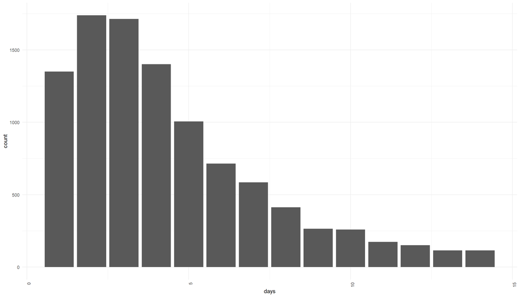

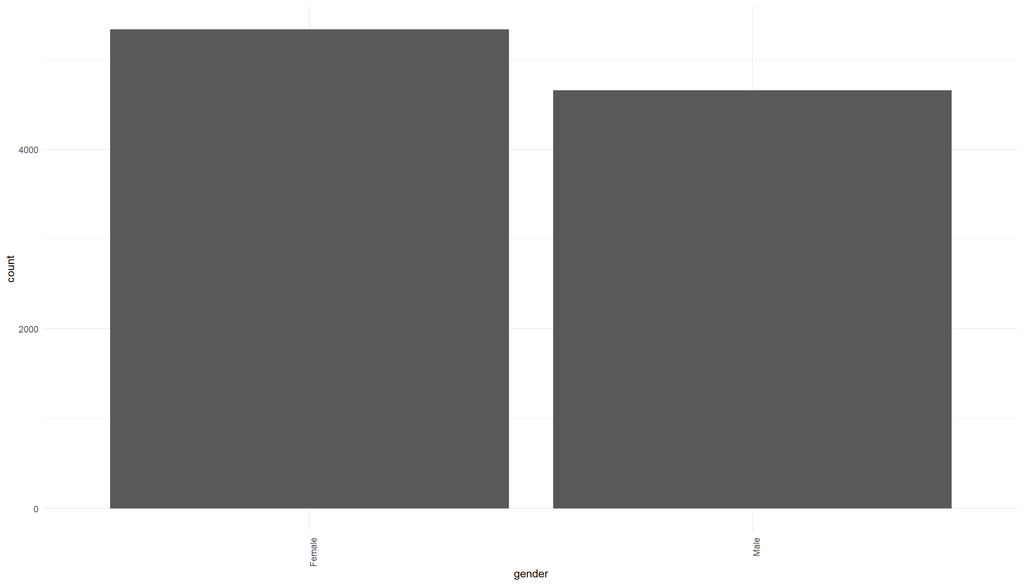

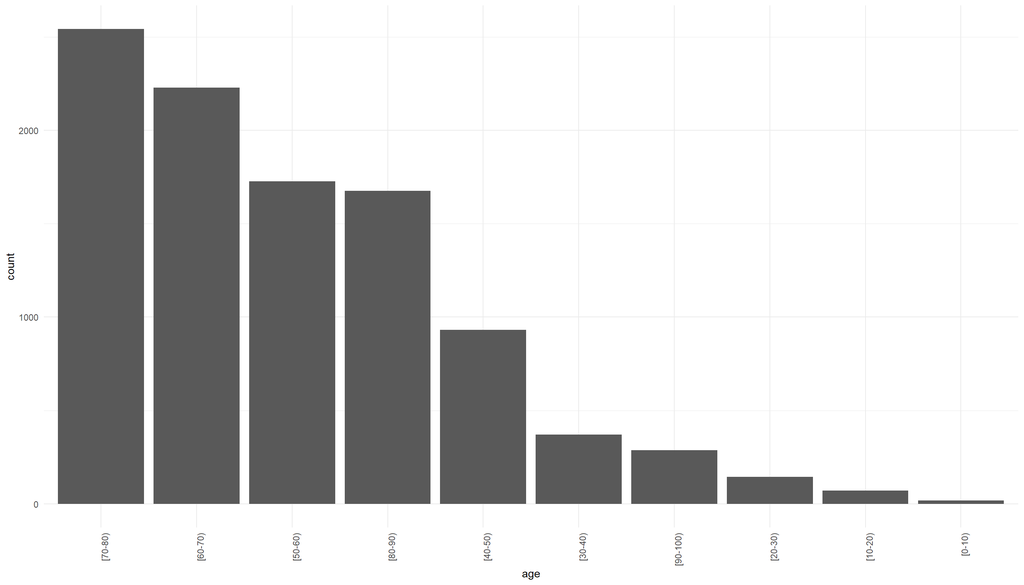

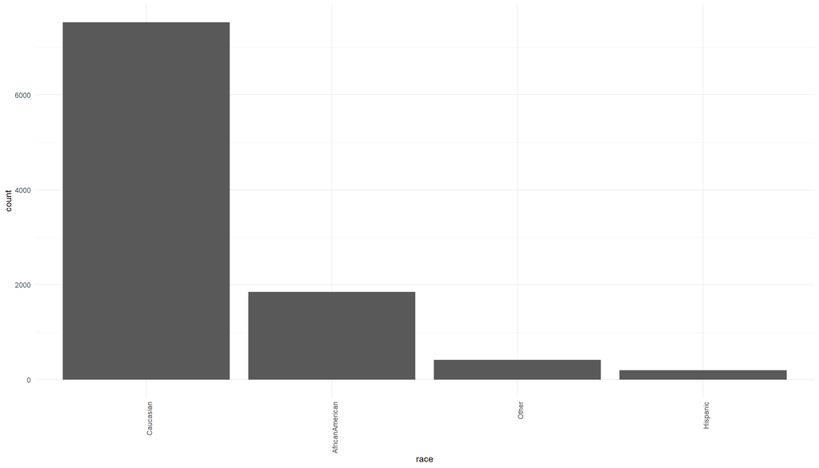

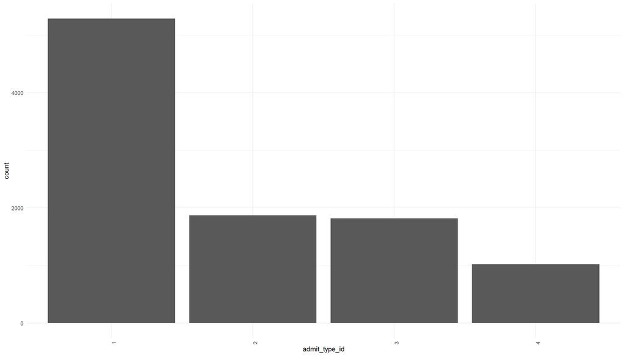

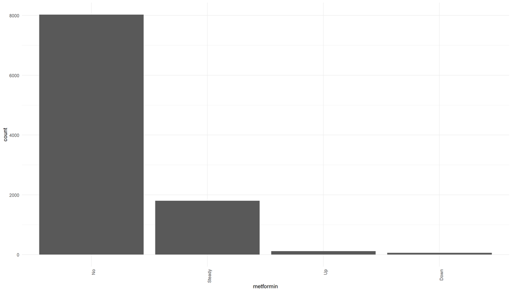

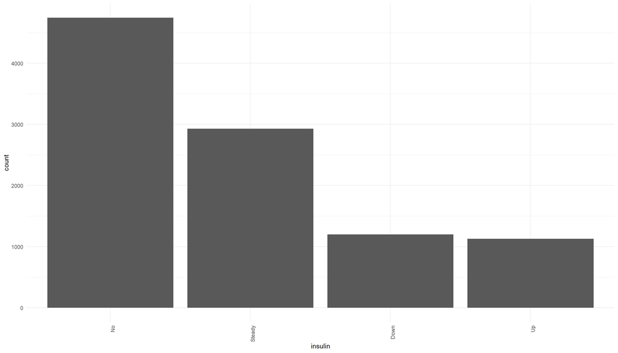

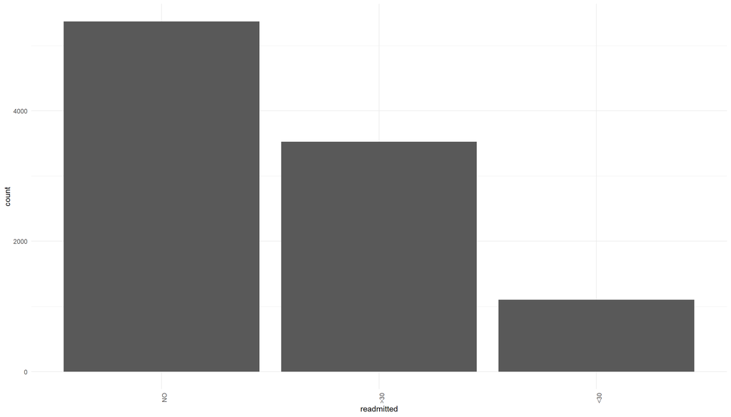

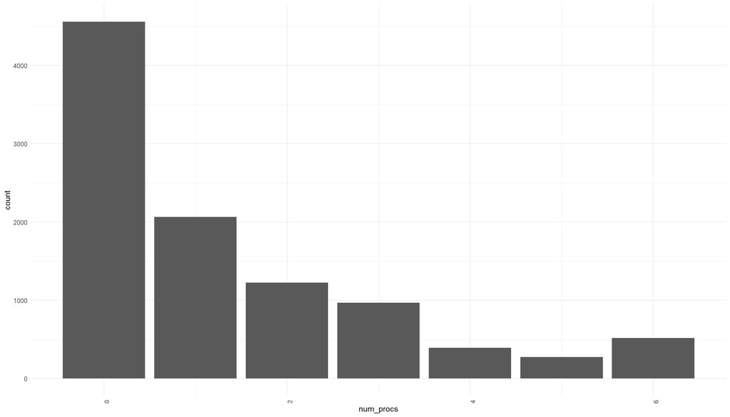

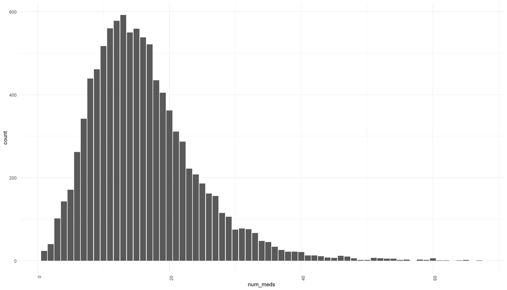

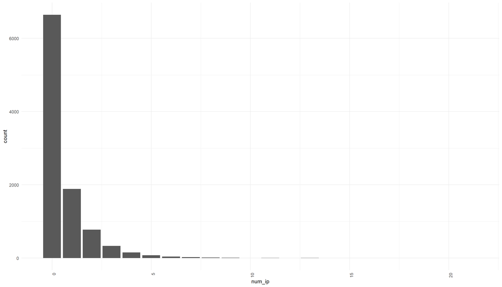

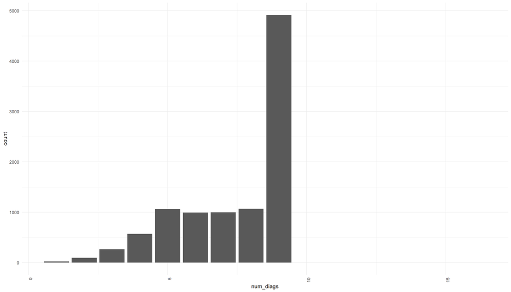

```r
library(ggplot2)
vars <- colnames(data.all)

for (i in vars) {
  plot <- ggplot(data.all, aes(x = unlist(data.all[, i]))) +
    geom_bar() +
    labs(x = i) +
    theme(axis.text.x = element_text(angle = 90, hjust = 1))
  print(plot)
}
```

```r
rm(i, vars, plot)
```

Target variable means by predictor variables.

```r
# This chunk provides means of the target variable split by predictors.
vars <- colnames(data.all)

for (i in vars) {
  x <- data.all %>%
    group_by_(i) %>%
    dplyr::summarise(
      mean = mean(days),
      median = median(days),
      n = dplyr::n()
    )

  print(x)
}
```

```
## # A tibble: 14 x 4
##     days  mean median     n
##    <dbl> <dbl>  <dbl> <int>
##  1     1     1      1  1350
##  2     2     2      2  1738
##  3     3     3      3  1713
##  4     4     4      4  1400
##  5     5     5      5  1005
##  6     6     6      6   714
##  7     7     7      7   585
##  8     8     8      8   413
##  9     9     9      9   265
## 10    10    10     10   259
## 11    11    11     11   174
## 12    12    12     12   151
```

[output cut: 113 more lines]

```r
rm(i, vars, x)
```

Correlations of the target variable to numeric variables and correlation matrix.

```r
# Calculate the correlation matrix for numeric variables
cor.matrix <- cor(data.all[, sapply(data.all, is.numeric)])

print("Correlation Matrix")
```

```
## [1] "Correlation Matrix"
```

```r
cor.matrix
```

```
##                 days   num_procs   num_meds      num_ip  num_diags
## days      1.00000000  0.19146613 0.47228051  0.06817037 0.20594715
## num_procs 0.19146613  1.00000000 0.37177495 -0.06492627 0.08153301
## num_meds  0.47228051  0.37177495 1.00000000  0.06649828 0.26594837
## num_ip    0.06817037 -0.06492627 0.06649828  1.00000000 0.10811761
## num_diags 0.20594715  0.08153301 0.26594837  0.10811761 1.00000000
```

Split histograms and boxplots of target by factor variables.

Copy and add code for other factors as needed.

```r
data.all %>% str()
```

```
## tibble [9,997 x 12] (S3: tbl_df/tbl/data.frame)
##  $ days         : num [1:9997] 1 5 2 12 6 3 1 3 9 1 ...
##  $ gender       : Factor w/ 2 levels "Female","Male": 2 2 1 2 2 1 2 1 1 2 ...
##  $ age          : Factor w/ 10 levels "[70-80)","[60-70)",..: 1 1 4 3 6 6 2 4 4 4 ...
##  $ race         : Factor w/ 4 levels "Caucasian","AfricanAmerican",..: 2 1 1 1 3 1 1 1 1 1 ...
##  $ admit_type_id: Factor w/ 4 levels "1","2","3","4": 1 3 2 1 2 2 1 1 4 1 ...
##  $ metformin    : Factor w/ 4 levels "No","Steady",..: 1 1 1 1 1 2 1 1 1 1 ...
##  $ insulin      : Factor w/ 4 levels "No","Steady",..: 3 2 2 4 2 1 2 1 2 2 ...
##  $ readmitted   : Factor w/ 3 levels "NO",">30","<30": 2 2 1 2 2 1 1 2 2 3 ...
##  $ num_procs    : num [1:9997] 0 5 1 2 2 1 0 0 0 0 ...
##  $ num_meds     : num [1:9997] 10 13 10 32 16 17 12 11 9 13 ...
##  $ num_ip       : num [1:9997] 0 0 0 0 1 0 0 0 0 0 ...
##  $ num_diags    : num [1:9997] 8 9 7 9 5 8 7 8 5 6 ...
```

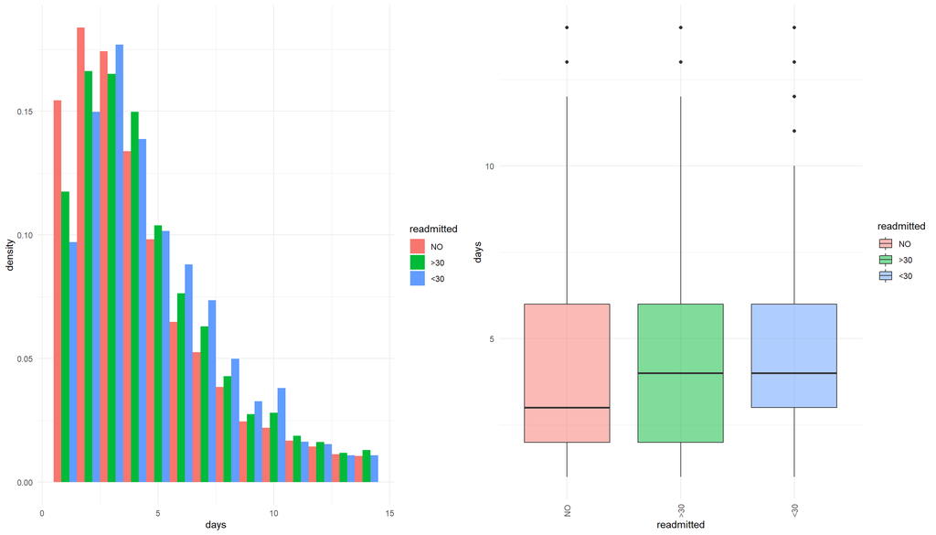

```r
library(gridExtra)

# Explore target days vs. gender.

# Split histogram
p1 <- ggplot(data.all, aes(
  x = days,
  group = readmitted   , fill = readmitted   , y = ..density..
)) +
  geom_histogram(position = "dodge", binwidth = 1) # Replace gender twice for other variables

# Boxplot
p2 <- ggplot(data = data.all, aes(
  x = readmitted   , y = days,
  fill = readmitted
)) +
  geom_boxplot(alpha = 0.5) +
  theme(axis.text.x = element_text(angle = 90, vjust = 0.5)) # Replace gender twice for other variables

grid.arrange(p1, p2, ncol = 2)
```

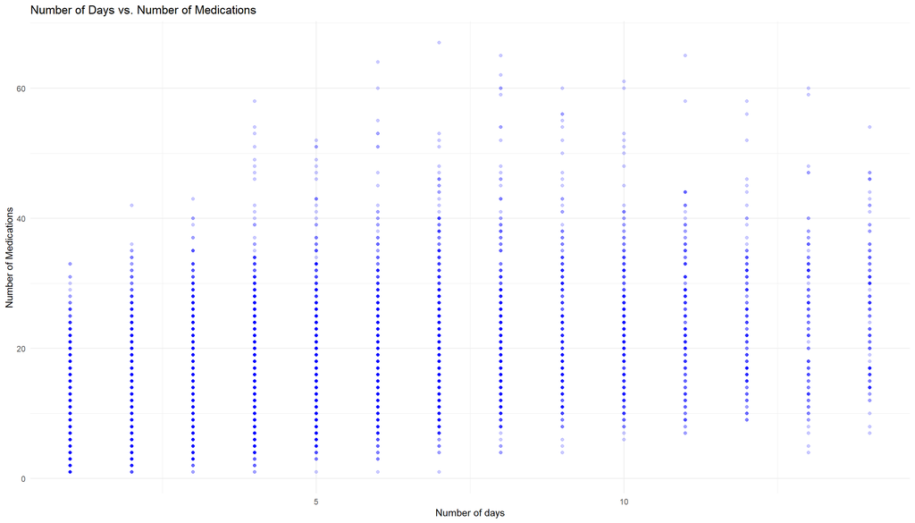

```r
library(dplyr)
library(ggplot2)
library(tidyverse)
data.all %>%
  ggplot(aes(days, num_meds )) +
  geom_point(size = 1.5, alpha = 0.2, color = "blue") +
  theme_minimal() +
  ggtitle("Number of Days vs. Number of Medications") +
  xlab("Number of days") +
  ylab("Number of Medications")
```

# Task 3

Consider two data issues.

No code provided.

# Task 4

Write a data summary for your actuarial manager.

No code provided.

# Task 5

Perform Principal Components Analysis (PCA).

The following chunk performs PCA on numeric variables.

```r
# Select only the variables used for PCA. Do not change this list.
data.pca <- data.all[, c("num_procs", "num_meds", "num_ip", "num_diags")]

# Run PCA on the numeric variables. Variables are centered and scaled.
pca <- prcomp(data.pca, center = TRUE, scale. = TRUE)
summary(pca)
```

```
## Importance of components:
##                           PC1    PC2    PC3    PC4
## Standard deviation     1.2267 1.0426 0.9141 0.7568
## Proportion of Variance 0.3762 0.2717 0.2089 0.1432
## Cumulative Proportion  0.3762 0.6479 0.8568 1.0000
```

```r
pca$rotation
```

```
##                 PC1         PC2         PC3        PC4
## num_procs 0.5572974 -0.44554566  0.36869207  0.5957977
## num_meds  0.6739567 -0.05424897  0.09615285 -0.7304752
## num_ip    0.1178855  0.79602911  0.58013950  0.1260112
## num_diags 0.4704307  0.40605883 -0.71990204  0.3091152
```

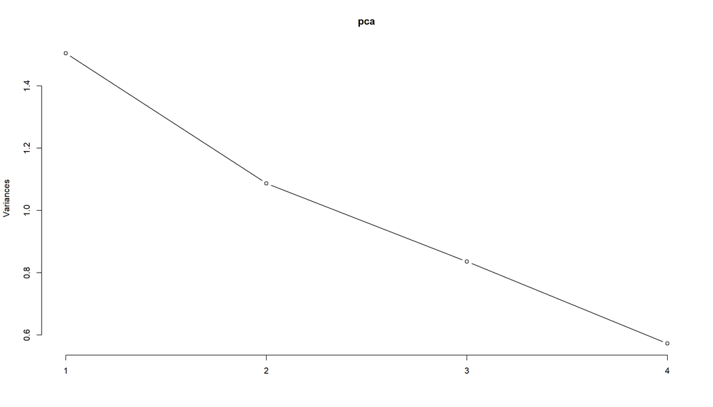

```r
plot(pca, type = "line")
```

The following chunk constructs a new feature using the first principal component and attaches it to the data frame.

```r
# Center and scale the variables
data.pca.std <- as.data.frame(scale(data.pca))
head(data.pca.std)
```

```
##    num_procs    num_meds     num_ip  num_diags
## 1 -0.7859605 -0.75344021 -0.5015546  0.2903831
## 2  2.1369050 -0.38640658 -0.5015546  0.8110001
## 3 -0.2013874 -0.75344021 -0.5015546 -0.2302338
## 4  0.3831857  1.93813974 -0.5015546  0.8110001
## 5  0.3831857 -0.01937295  0.2836069 -1.2714678
## 6 -0.2013874  0.10297159 -0.5015546  0.2903831
```

```r
# Add the first principal component to the data frame.
data.all$PC1 <- pca$x[, 1]
str(data.all$PC1)
```

```
##  num [1:9997] -0.868 1.253 -0.787 1.842 -0.364 ...
```

Split the data into training and test data sets.

```r
# Split the data into training and test data sets.

library(caret)
set.seed(100)
train_ind <- createDataPartition(data.all$days, p = 0.7, list = FALSE)
data.train <- data.all[train_ind, ]
data.test <- data.all[-train_ind, ]

print("TRAIN")
```

```
## [1] "TRAIN"
```

```r
mean(data.train$days)
```

```
## [1] 4.397857
```

```r
print("TEST")
```

```
## [1] "TEST"
```

```r
mean(data.test$days)
```

```
## [1] 4.435769
```

```r
print("ALL")
```

```
## [1] "ALL"
```

```r
mean(data.all$days)
```

```
## [1] 4.409223
```

```r
rm(train_ind)
```

# Task 6

Construct a decision tree.

Construct an unpruned regression tree. Do not use PC1. Do not change the code.

```r
library(rpart)
library(rpart.plot)
set.seed(555)

# Fit the model
tree1 <- rpart(days ~ . - PC1,
  data = data.train,
  method = "anova",
  control = rpart.control(cp = 0.001, minbucket = 20)
)

tree1
```

```
## n= 7000
##
## node), split, n, deviance, yval
##       * denotes terminal node
##
##   1) root 7000 62304.9700 4.397857
##     2) num_meds< 21.5 5559 36673.0600 3.804281
##       4) num_meds< 13.5 2985 14840.8000 3.200670
##         8) num_meds< 8.5 1069  3351.6670 2.612722 *
##         9) num_meds>=8.5 1916 10913.4200 3.528706
##          18) num_ip< 0.5 1322  6623.7370 3.352496
##            36) age=[60-70),[50-60),[30-40),[10-20),[0-10) 562  2609.4310 3.067616 *
##            37) age=[70-80),[80-90),[40-50),[90-100),[20-30) 760  3934.9680 3.563158 *
##          19) num_ip>=0.5 594  4157.2810 3.920875
##            38) admit_type_id=1,4 404  2072.2080 3.608911 *
##            39) admit_type_id=2,3 190  1962.1530 4.584211
##              78) insulin=Steady,Up 86   593.7209 3.837209 *
##              79) insulin=No,Down 104  1280.7600 5.201923 *
##       5) num_meds>=13.5 2574 19483.4500 4.504274
##        10) age=[60-70),[50-60),[40-50),[30-40),[20-30) 1351  9365.5000 4.162102
##          20) num_meds< 16.5 568  3306.3940 3.676056
##            40) admit_type_id=1,3,4 448  2265.9910 3.504464 *
##            41) admit_type_id=2 120   977.9667 4.316667 *
##          21) num_meds>=16.5 783  5827.5810 4.514687
##            42) admit_type_id=3,4 250  1814.8640 3.888000
##              84) num_diags< 5.5 67   237.1940 2.835821 *
##              85) num_diags>=5.5 183  1476.3390 4.273224 *
##            43) admit_type_id=1,2 533  3868.4800 4.808630 *
##        11) age=[70-80),[80-90),[90-100),[10-20),[0-10) 1223  9785.0450 4.882257
##          22) admit_type_id=1,3,4 1003  7369.0690 4.698903
##            44) race=Caucasian,Other,Hispanic 888  6097.9990 4.582207
##              88) age=[70-80),[80-90) 825  5594.2500 4.500606 *
##              89) age=[90-100),[10-20) 63   426.3175 5.650794 *
##            45) race=AfricanAmerican 115  1165.6000 5.600000 *
##          23) admit_type_id=2 220  2228.5270 5.718182
##            46) readmitted=NO,>30 200  1773.9550 5.515000
##              92) num_meds< 19.5 162  1331.4380 5.216049 *
##              93) num_meds>=19.5 38   366.3158 6.789474 *
##            47) readmitted=<30 20   363.7500 7.750000 *
##     3) num_meds>=21.5 1441 16117.4700 6.687717
```

[output cut: 11 more lines]

```
##             109) insulin=No,Up 118  1183.1530 6.915254 *
##            55) age=[60-70),[80-90),[90-100) 148  1648.8110 7.378378 *
##       7) num_meds>=27.5 598  6456.6910 7.767559
##        14) admit_type_id=3,4 262  2721.9580 6.690840
##          28) num_procs< 3.5 158  1600.9430 6.018987
##            56) insulin=No,Steady 107   923.9065 5.411215
##             112) admit_type_id=3 79   507.4684 4.860759 *
##             113) admit_type_id=4 28   324.9643 6.964286 *
##            57) insulin=Down,Up 51   554.5882 7.294118 *
##          29) num_procs>=3.5 104   941.3462 7.711538 *
##        15) admit_type_id=1,2 336  3194.1430 8.607143
##          30) num_procs< 0.5 36   232.9722 6.472222 *
##          31) num_procs>=0.5 300  2777.3970 8.863333
##            62) num_meds< 30.5 100  1061.3100 8.130000 *
##            63) num_meds>=30.5 200  1635.4200 9.230000 *
```

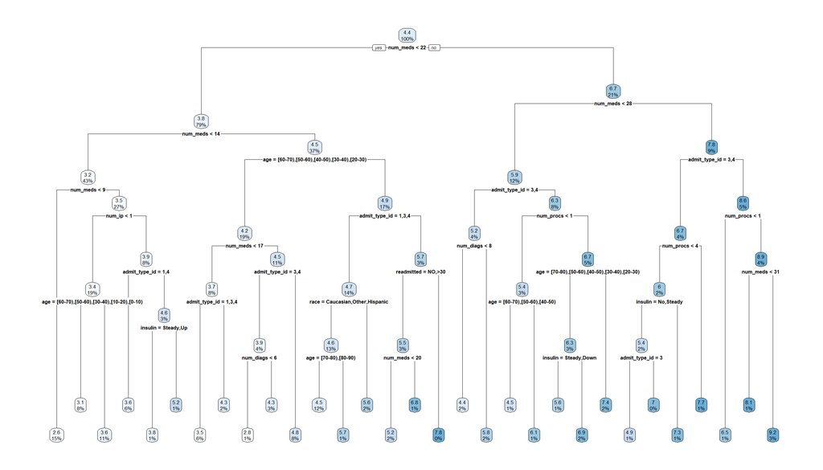

```r
# Plot the tree
rpart.plot(tree1)
```

```r
# Predict on training data
tree1.pred.train <- predict(tree1, data.train, type = "vector")

# Calculate the Pearson goodness-of-fit statistic on training data
sum((data.train$days - tree1.pred.train)^2 / tree1.pred.train) / nrow(data.train)
```

```
## [1] 1.452799
```

```r
# Predict on test data
tree1.pred.test <- predict(tree1, data.test, type = "vector")

# Calculate the Pearson goodness-of-fit statistic on test data
sum((data.test$days - tree1.pred.test)^2 / tree1.pred.test) / nrow(data.test)
```

```
## [1] 1.55681
```

Use cost-complexity pruning to produce a reduced tree.

```r
# Display the complexity parameter table and plot for tree1.
tree1$cptable
```

```
##             CP nsplit rel error    xerror       xstd
## 1  0.152707521      0 1.0000000 1.0001587 0.02033349
## 2  0.037698542      1 0.8472925 0.8480251 0.01798971
## 3  0.019130886      2 0.8095939 0.8107041 0.01729121
## 4  0.009240202      3 0.7904631 0.7966838 0.01725127
## 5  0.008676511      4 0.7812228 0.7926694 0.01717010
## 6  0.005343208      5 0.7725463 0.7839649 0.01699532
## 7  0.003715982      6 0.7672031 0.7777088 0.01689852
## 8  0.003568539      7 0.7634871 0.7773847 0.01695395
## 9  0.003008571      9 0.7563501 0.7762636 0.01695438
## 10 0.002949588     10 0.7533415 0.7720921 0.01690122
## 11 0.002883700     11 0.7503919 0.7720237 0.01692143
## 12 0.002491909     12 0.7475082 0.7707511 0.01692526
## 13 0.002315013     13 0.7450163 0.7713557 0.01695682
## 14 0.002125084     14 0.7427013 0.7712409 0.01695252
```

[output cut: 16 more lines]

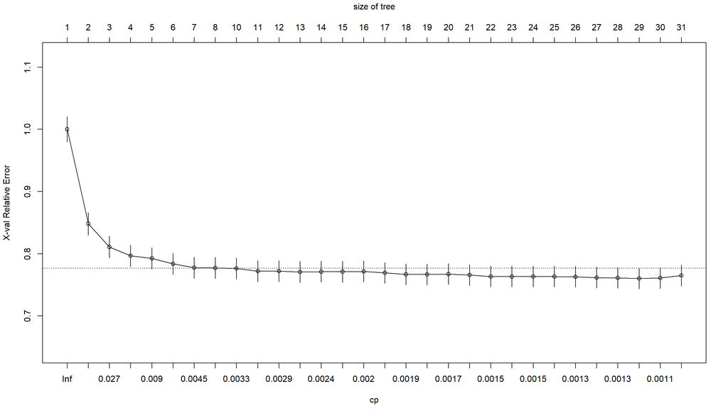

```r
plotcp(tree1)
```

```r
# Prune the tree by replacing XX with the complexity parameter that will result in eight leaves.
# If eight is not a possible option, select the largest number less than eight that is possible.
tree2 <- prune(tree1, cp = 0.003568539) # Replace XX.

tree2
```

```
## n= 7000
##
## node), split, n, deviance, yval
##       * denotes terminal node
##
##  1) root 7000 62304.970 4.397857
##    2) num_meds< 21.5 5559 36673.060 3.804281
##      4) num_meds< 13.5 2985 14840.800 3.200670
##        8) num_meds< 8.5 1069  3351.667 2.612722 *
##        9) num_meds>=8.5 1916 10913.420 3.528706 *
##      5) num_meds>=13.5 2574 19483.450 4.504274
##       10) age=[60-70),[50-60),[40-50),[30-40),[20-30) 1351  9365.500 4.162102
##         20) num_meds< 16.5 568  3306.394 3.676056 *
##         21) num_meds>=16.5 783  5827.581 4.514687 *
##       11) age=[70-80),[80-90),[90-100),[10-20),[0-10) 1223  9785.045 4.882257 *
##    3) num_meds>=21.5 1441 16117.470 6.687717
##      6) num_meds< 27.5 843  8468.833 5.921708 *
##      7) num_meds>=27.5 598  6456.691 7.767559
##       14) admit_type_id=3,4 262  2721.958 6.690840 *
##       15) admit_type_id=1,2 336  3194.143 8.607143 *
```

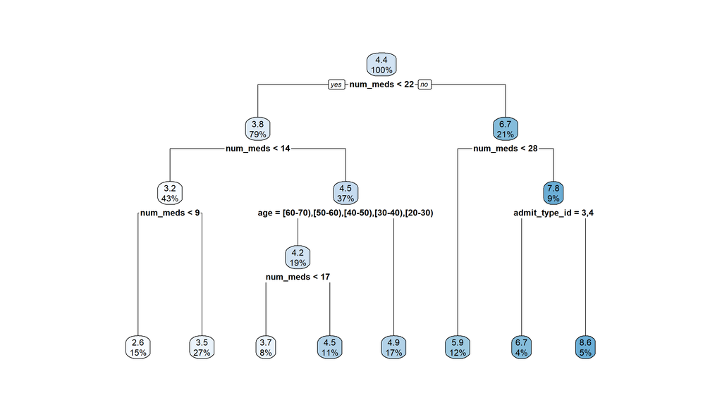

```r
# Plot the tree
rpart.plot(tree2)
```

```r
# Predict on training data
tree2.pred.train <- predict(tree2, data.train, type = "vector")

# Calculate the Pearson goodness-of-fit statistic on training data
sum((data.train$days - tree2.pred.train)^2 / tree2.pred.train) / nrow(data.train)
```

```
## [1] 1.539727
```

```r
# Predict on test data
tree2.pred.test <- predict(tree2, data.test, type = "vector")

# Calculate the Pearson goodness-of-fit statistic on test data
sum((data.test$days - tree2.pred.test)^2 / tree2.pred.test) / nrow(data.test)
```

```
## [1] 1.596192
```

# Task 7

Construct a generalized linear model (GLM).

Fit a GLM with all original variables included but excluding the PCA variable. Do not change the Poisson distribution or log link function.

```r
# Fit the model
glm1 <- glm(days ~ . - PC1,
  data = data.train,
  family = poisson(link = "log") # Do not change.
)

summary(glm1)
```

```
##
## Call:
## glm(formula = days ~ . - PC1, family = poisson(link = "log"),
##     data = data.train)
##
## Deviance Residuals:
##     Min       1Q   Median       3Q      Max
## -3.6791  -0.9798  -0.2834   0.5748   4.8223
##
## Coefficients:
##                       Estimate Std. Error z value Pr(>|z|)
## (Intercept)          0.7179703  0.0316229  22.704  < 2e-16 ***
## genderMale          -0.0348400  0.0116236  -2.997 0.002723 **
## age[60-70)          -0.0805106  0.0165719  -4.858 1.18e-06 ***
## age[50-60)          -0.1342346  0.0181664  -7.389 1.48e-13 ***
## age[80-90)           0.0648094  0.0174044   3.724 0.000196 ***
## age[40-50)          -0.1042567  0.0225005  -4.634 3.59e-06 ***
## age[30-40)          -0.0929152  0.0342933  -2.709 0.006740 **
## age[90-100)          0.1144602  0.0347736   3.292 0.000996 ***
## age[20-30)          -0.1015377  0.0580091  -1.750 0.080054 .
## age[10-20)           0.0457339  0.0747208   0.612 0.540495
## age[0-10)            0.0302069  0.1679155   0.180 0.857236
## raceAfricanAmerican  0.1156573  0.0150857   7.667 1.77e-14 ***
## raceOther            0.0509221  0.0291368   1.748 0.080518 .
## raceHispanic         0.0876614  0.0421711   2.079 0.037644 *
## admit_type_id2       0.1254435  0.0152688   8.216  < 2e-16 ***
## admit_type_id3      -0.0858340  0.0163343  -5.255 1.48e-07 ***
## admit_type_id4      -0.0230973  0.0200092  -1.154 0.248363
## metforminSteady     -0.0156711  0.0152461  -1.028 0.304007
## metforminUp          0.1526204  0.0472482   3.230 0.001237 **
## metforminDown        0.0674198  0.0716793   0.941 0.346922
## insulinSteady       -0.0222760  0.0137654  -1.618 0.105608
## insulinDown         -0.0109830  0.0186137  -0.590 0.555157
## insulinUp            0.0237683  0.0188068   1.264 0.206296
## readmitted>30        0.0423494  0.0125898   3.364 0.000769 ***
## readmitted<30        0.0793006  0.0189584   4.183 2.88e-05 ***
## num_procs            0.0112080  0.0036594   3.063 0.002193 **
## num_meds             0.0308537  0.0007074  43.618  < 2e-16 ***
## num_ip               0.0140475  0.0044002   3.192 0.001411 **
## num_diags            0.0273086  0.0035108   7.779 7.34e-15 ***
## ---
## Signif. codes:  0 '***' 0.001 '**' 0.01 '*' 0.05 '.' 0.1 ' ' 1
##
## (Dispersion parameter for poisson family taken to be 1)
##
##     Null deviance: 13093.4  on 6999  degrees of freedom
## Residual deviance:  9800.4  on 6971  degrees of freedom
## AIC: 31881
##
## Number of Fisher Scoring iterations: 5
```

```r
# Predict on training data
glm1.pred.train <- predict(glm1, data.train, type = "response")

# Calculate the Pearson goodness-of-fit statistic on training data
sum((data.train$days - glm1.pred.train)^2 / glm1.pred.train) / nrow(data.train)
```

```
## [1] 1.525184
```

```r
# Predict on test data
glm1.pred.test <- predict(glm1, data.test, type = "response")

# Calculate the Pearson goodness-of-fit statistic on test data
sum((data.test$days - glm1.pred.test)^2 / glm1.pred.test) / nrow(data.test)
```

```
## [1] 1.558293
```

Fit a GLM with the PCA variable created in Task 5 included (and without the numeric variables used to produce the PCA variable). Do not change the Poisson distribution or log link function.

```r
# Fit the model
glm2 <- glm(days ~ . - num_procs - num_meds - num_ip - num_diags,
  data = data.train,
  family = poisson(link = "log") # Do not change.
)

summary(glm2)
```

```
##
## Call:
## glm(formula = days ~ . - num_procs - num_meds - num_ip - num_diags,
##     family = poisson(link = "log"), data = data.train)
##
## Deviance Residuals:
##     Min       1Q   Median       3Q      Max
## -3.1608  -1.0018  -0.2769   0.5798   5.2020
##
## Coefficients:
##                       Estimate Std. Error z value Pr(>|z|)
## (Intercept)          1.4274774  0.0164263  86.902  < 2e-16 ***
## genderMale          -0.0494009  0.0115944  -4.261 2.04e-05 ***
## age[60-70)          -0.0756218  0.0165587  -4.567 4.95e-06 ***
## age[50-60)          -0.1348693  0.0181158  -7.445 9.71e-14 ***
## age[80-90)           0.0674664  0.0173787   3.882 0.000104 ***
## age[40-50)          -0.1043704  0.0223953  -4.660 3.16e-06 ***
## age[30-40)          -0.0977437  0.0341083  -2.866 0.004161 **
## age[90-100)          0.1120759  0.0347428   3.226 0.001256 **
## age[20-30)          -0.1171011  0.0574331  -2.039 0.041459 *
## age[10-20)           0.0937937  0.0739844   1.268 0.204887
## age[0-10)            0.0955944  0.1675305   0.571 0.568265
## raceAfricanAmerican  0.1232452  0.0150404   8.194 2.52e-16 ***
## raceOther            0.0519935  0.0290797   1.788 0.073781 .
## raceHispanic         0.0852135  0.0421685   2.021 0.043302 *
## admit_type_id2       0.0927311  0.0151014   6.141 8.22e-10 ***
## admit_type_id3      -0.0887712  0.0159217  -5.575 2.47e-08 ***
## admit_type_id4      -0.0123482  0.0198530  -0.622 0.533953
## metforminSteady      0.0265848  0.0150922   1.761 0.078156 .
## metforminUp          0.2135528  0.0471570   4.529 5.94e-06 ***
## metforminDown        0.1568136  0.0715433   2.192 0.028389 *
## insulinSteady       -0.0009764  0.0136985  -0.071 0.943177
## insulinDown          0.0475165  0.0183216   2.593 0.009501 **
## insulinUp            0.0854854  0.0185214   4.615 3.92e-06 ***
## readmitted>30        0.0413499  0.0123905   3.337 0.000846 ***
## readmitted<30        0.0872897  0.0186084   4.691 2.72e-06 ***
## PC1                  0.2169486  0.0044439  48.820  < 2e-16 ***
## ---
## Signif. codes:  0 '***' 0.001 '**' 0.01 '*' 0.05 '.' 0.1 ' ' 1
##
## (Dispersion parameter for poisson family taken to be 1)
##
##     Null deviance: 13093  on 6999  degrees of freedom
## Residual deviance: 10245  on 6974  degrees of freedom
## AIC: 32320
##
## Number of Fisher Scoring iterations: 5
```

```r
# Predict on training data
glm2.pred.train <- predict(glm2, data.train, type = "response")

# Calculate the Pearson goodness-of-fit statistic on training data
sum((data.train$days - glm2.pred.train)^2 / glm2.pred.train) / nrow(data.train)
```

```
## [1] 1.587999
```

```r
# Predict on test data
glm2.pred.test <- predict(glm2, data.test, type = "response")

# Calculate the Pearson goodness-of-fit statistic on test data
sum((data.test$days - glm2.pred.test)^2 / glm2.pred.test) / nrow(data.test)
```

```
## [1] 1.618514
```

# Task 8

Perform feature selection with lasso regression.

Use cross-validation to determine appropriate level of lambda for lasso regression.

```r
library(glmnet)

# Format data as matrices (necessary for glmnet). Uncomment two items that reflect your decision from Task 7.

lasso.mat.train <- model.matrix(days ~ . - PC1, data.train)
lasso.mat.test <- model.matrix(days ~ . - PC1, data.test)
# lasso.mat.train <- model.matrix(days ~ . - num_procs - num_meds - num_ip - num_diags, data.train)
# lasso.mat.test <- model.matrix(days ~ . - num_procs - num_meds - num_ip - num_diags, data.test)

set.seed(789)

lasso.cv <- cv.glmnet(
  x = lasso.mat.train,
  y = data.train$days,
  family = "poisson", # Do not change.
  alpha = 1 # alpha = 1 for lasso
)
```

Use the cross-validation results to run the final lasso regression model.

```r
# Fit the model
lasso <- glmnet(
  x = lasso.mat.train,
  y = data.train$days,
  family = "poisson", # Do not change.
  lambda = lasso.cv$lambda.1se,
  alpha = 1 # alpha = 1 for lasso
)

# List variables
lasso$beta
```

```
## 29 x 1 sparse Matrix of class "dgCMatrix"
##                                s0
## (Intercept)          .
## genderMale          -0.0005247084
## age[60-70)           .
## age[50-60)          -0.0318520898
## age[80-90)           0.0609863438
## age[40-50)           .
## age[30-40)           .
## age[90-100)          0.0271444979
## age[20-30)           .
## age[10-20)           .
## age[0-10)            .
## raceAfricanAmerican  0.0408150599
## raceOther            .
## raceHispanic         .
## admit_type_id2       0.0879293247
## admit_type_id3      -0.0365864924
## admit_type_id4       .
## metforminSteady      .
## metforminUp          .
## metforminDown        .
## insulinSteady        .
## insulinDown          .
## insulinUp            .
## readmitted>30        .
## readmitted<30        0.0014827045
## num_procs            .
## num_meds             0.0296963221
## num_ip               0.0025137279
## num_diags            0.0223963381
```

```r
# Predict on training data
lasso.pred.train <- predict(lasso, lasso.mat.train, type = "response")

# Calculate the Pearson goodness-of-fit statistic on training data
sum((data.train$days - lasso.pred.train)^2 / lasso.pred.train) / nrow(data.train)
```

```
## [1] 1.541731
```

```r
# Predict on test data
lasso.pred.test <- predict(lasso, lasso.mat.test, type = "response")

# Calculate the Pearson goodness-of-fit statistic on test data
sum((data.test$days - lasso.pred.test)^2 / lasso.pred.test) / nrow(data.test)
```

```
## [1] 1.572154
```

# Task 9

No code provided.

# Task 10

No code provided.

# Task 11

Interpret the model for the client.

Copy the GLM code for the recommended model from Task 7 and run on the full dataset to interpret coefficients.

```r
glmall <- glm(days ~ . - PC1,
  data = data.all,
  family = poisson(link = "log") # Do not change.
)

summary(glmall)
```

```
##
## Call:
## glm(formula = days ~ . - PC1, family = poisson(link = "log"),
##     data = data.all)
##
## Deviance Residuals:
##     Min       1Q   Median       3Q      Max
## -3.7965  -0.9901  -0.2796   0.5750   4.8462
##
## Coefficients:
##                       Estimate Std. Error z value Pr(>|z|)
## (Intercept)          0.6883707  0.0265150  25.962  < 2e-16 ***
## genderMale          -0.0294931  0.0097078  -3.038 0.002381 **
## age[60-70)          -0.0807201  0.0137207  -5.883 4.03e-09 ***
## age[50-60)          -0.1313080  0.0151954  -8.641  < 2e-16 ***
## age[80-90)           0.0654817  0.0145591   4.498 6.87e-06 ***
## age[40-50)          -0.0963300  0.0190830  -5.048 4.47e-07 ***
## age[30-40)          -0.0981422  0.0286750  -3.423 0.000620 ***
## age[90-100)          0.1196640  0.0288625   4.146 3.38e-05 ***
## age[20-30)          -0.0991133  0.0458667  -2.161 0.030703 *
## age[10-20)           0.0041433  0.0685179   0.060 0.951781
## age[0-10)            0.1185523  0.1323537   0.896 0.370400
## raceAfricanAmerican  0.0930543  0.0126335   7.366 1.76e-13 ***
## raceOther            0.0399245  0.0239943   1.664 0.096129 .
## raceHispanic         0.0753598  0.0351906   2.141 0.032236 *
## admit_type_id2       0.1011927  0.0126976   7.969 1.59e-15 ***
## admit_type_id3      -0.0965640  0.0137104  -7.043 1.88e-12 ***
## admit_type_id4      -0.0369571  0.0169087  -2.186 0.028838 *
## metforminSteady     -0.0111182  0.0127266  -0.874 0.382325
## metforminUp          0.1690942  0.0402242   4.204 2.62e-05 ***
## metforminDown        0.0935513  0.0585593   1.598 0.110143
## insulinSteady       -0.0227393  0.0115314  -1.972 0.048615 *
## insulinDown         -0.0009650  0.0154185  -0.063 0.950097
## insulinUp            0.0234907  0.0155225   1.513 0.130196
## readmitted>30        0.0351538  0.0105473   3.333 0.000859 ***
## readmitted<30        0.0607342  0.0157007   3.868 0.000110 ***
## num_procs            0.0122912  0.0030398   4.043 5.27e-05 ***
## num_meds             0.0311647  0.0005936  52.499  < 2e-16 ***
## num_ip               0.0159963  0.0037234   4.296 1.74e-05 ***
## num_diags            0.0317179  0.0029255  10.842  < 2e-16 ***
## ---
## Signif. codes:  0 '***' 0.001 '**' 0.01 '*' 0.05 '.' 0.1 ' ' 1
##
## (Dispersion parameter for poisson family taken to be 1)
##
##     Null deviance: 18801  on 9996  degrees of freedom
## Residual deviance: 14039  on 9968  degrees of freedom
## AIC: 45569
##
## Number of Fisher Scoring iterations: 5
```

```r
summary(data.all)
```

```
##       days           gender          age                    race
##  Min.   : 1.000   Female:5338   [70-80):2541   Caucasian      :7531
##  1st Qu.: 2.000   Male  :4659   [60-70):2228   AfricanAmerican:1848
##  Median : 4.000                 [50-60):1726   Other          : 419
##  Mean   : 4.409                 [80-90):1676   Hispanic       : 199
##  3rd Qu.: 6.000                 [40-50): 931
##  Max.   :14.000                 [30-40): 372
##                                 (Other): 523
##  admit_type_id  metformin      insulin     readmitted   num_procs
##  1:5289        No    :8024   No    :4742   NO :5370   Min.   :0.000
##  2:1870        Steady:1799   Steady:2928   >30:3525   1st Qu.:0.000
##  3:1817        Up    : 114   Down  :1198   <30:1102   Median :1.000
##  4:1021        Down  :  60   Up    :1129              Mean   :1.345
##                                                       3rd Qu.:2.000
##                                                       Max.   :6.000
##
##     num_meds         num_ip          num_diags           PC1
##  Min.   : 1.00   Min.   : 0.0000   Min.   : 1.000   Min.   :-3.2424
##  1st Qu.:10.00   1st Qu.: 0.0000   1st Qu.: 6.000   1st Qu.:-0.7883
##  Median :15.00   Median : 0.0000   Median : 8.000   Median :-0.1186
##  Mean   :16.16   Mean   : 0.6388   Mean   : 7.442   Mean   : 0.0000
##  3rd Qu.:20.00   3rd Qu.: 1.0000   3rd Qu.: 9.000   3rd Qu.: 0.6878
##  Max.   :67.00   Max.   :21.0000   Max.   :16.000   Max.   : 5.9067
##
```

# Task 12

No code provided.